# Análisis Espacio-Temporal de Homicidios en Ecuador

Evaluación de Recurrencia y Relación con Amenidades Urbanas (2014-2026)

Autor/a

Daniel Lara Del Salto

Fecha de publicación

30 de mayo de 2026

## 1 INTRODUCCIÓN

### 1.1 Problemática

Ecuador enfrenta una escalada de violencia letal sin precedentes desde 2021. El análisis de los datos oficiales revela que estos homicidios no ocurren de forma aleatoria, sino que exhiben un agudo comportamiento de “contagio” espacio-temporal, donde un evento violento desencadena rápidamente otros en su entorno inmediato, formando *hot spots* altamente volátiles.

¿En qué medida la proximidad espacial a específicos nodos o amenidades urbanas determina la intensidad de recurrencia de los homicidios en las zonas de mayor riesgo del país?

### 1.2 Descripción de los Datos y Variables

El presente análisis se fundamenta en los registros oficiales de Homicidios Intencionales, obtenidos del portal de Datos Abiertos Ecuador. La base de datos original se estructuró a partir de la consolidación de dos fuentes: la información histórica que abarca el periodo 2014 - 2025 y la actualización más reciente que cubre enero y febrero de 2026. Se cuenta con 31892 observaciones y 35 variables que describen el fenómeno criminal en múltiples dimensiones:

1. **Dimensión Espacial y Administrativa**
   - Geografía Policial y Política: zona, subzona, distrito, circuito, subcircuito, provincia y cantón.
   - Entorno del Suceso: area_hecho, lugar, tipo_lugar
   - Geolocalización: longitud, latitud.
2. **Dimensión Temporal**
   - fecha_infracción (YYYY-MM-DD), hora_infraccion (HH:MM:SS)
3. **Dimensión Criminológica y Contextual**
   - Clasificación del Delito: tipo_muerte
   - Mecanismo: arma, tipo_arma
   - Causa y Motivación: presunta_motivacion, presun_motiva_observada, probable_causa_motivada
4. **Perfil Demográfico de la Víctima**
   - Características sociodemográficas: edad, sexo, genero, etnia, estado_civil, nacionalidad, instruccion, discapacidad y profesion_registro_civil

```
Marked planar point pattern: 31892 points
Mark variables:
   provincia canton tipo_muerte arma presunta_motivacion lugar sexo edad
window: rectangle = [-80.98647, -75.42469] x [-4.97405, 1.42759] units
```

```
Marked planar point pattern:  31892 points
Average intensity 895.7289 points per square unit

*Pattern contains duplicated points*

Coordinates are given to 16 decimal places

Mark variables: provincia, canton, tipo_muerte, arma, presunta_motivacion,
lugar, sexo, edad
Summary:
      provincia            canton         tipo_muerte
 GUAYAS    :13475   GUAYAQUIL : 8294   ASESINATO:28581
 MANABÍ    : 3820   DURÁN     : 1647   FEMICIDIO:  624
 LOS RÍOS  : 3801   QUITO     : 1561   HOMICIDIO: 2481
 EL ORO    : 2550   MACHALA   : 1129   SICARIATO:  206
 PICHINCHA : 1778   MANTA     : 1093
 ESMERALDAS: 1738   ESMERALDAS: 1014
 (Other)   : 4730   (Other)   :17154
               arma                    presunta_motivacion
 ARMA BLANCA     : 3768   DELINCUENCIA COMÚN     :26862
 ARMA CONTUNDENTE:  857   VIOLENCIA COMUNITARIA  : 3493
 ARMA DE FUEGO   :25464   VIOLENCIA INTRAFAMILIAR: 1109
 CONSTRICTORA    :  496   TRANSNACIONAL          :  310
 OTROS           : 1273   TERRORISMO             :   55
 SUSTANCIAS      :   34   VIOLENCIA SEXUAL       :   36
                          (Other)                :   27
                              lugar                   sexo
 VÍA PÚBLICA                     :19644   HOMBRE        :28732
 CASA/VILLA                      : 4806   MUJER         : 3006
 FINCA                           :  961   NO DETERMINADO:  154
 TERRENO BALDÍO                  :  782
 CENTROS DE REHABILITACIÓN SOCIAL:  497
 RÍO                             :  495
 (Other)                         : 4707
     edad
 Length:31892
 Class :character
 Mode  :character





Window: rectangle = [-80.98647, -75.42469] x [-4.97405, 1.42759] units
                    (5.562 x 6.402 units)
Window area = 35.6045 square units
```

## 2 Datos

### 2.1 Ocurrencia de los datos

#### 2.1.1 Nivel de provincia

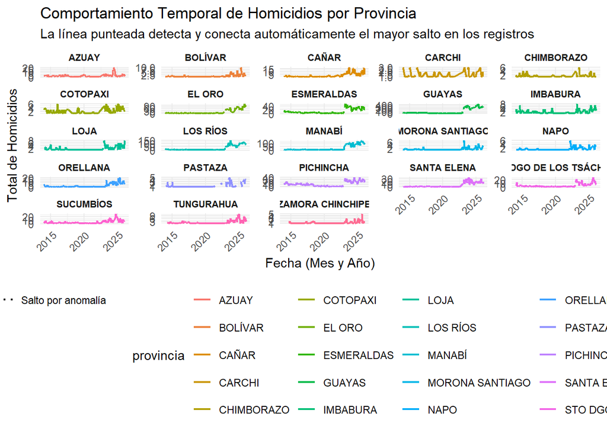

#### 2.1.2 Nivel Nacional

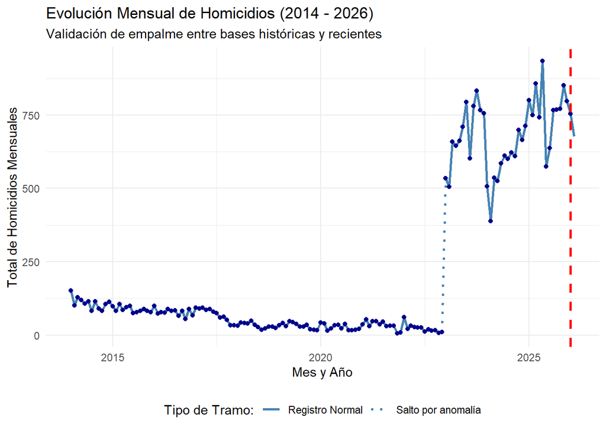

## 3 Análisis Espacio-Temporal

El primer paso metodológico consistió en cuantificar la volatilidad espacial de cada evento violento. Basados en la teoría criminológica del contagio (*Near-Repeat*), se estableció una ventana espacio-temporal para detectar cuántos eventos subsecuentes fueron “detonados” por un homicidio inicial. Se definió un evento como “vecino próximo” si cumplía simultáneamente con las siguientes condiciones paramétricas:

- **Proximidad Espacial:** $\delta_s \le 500$ metros
- **Proximidad temporal:** $0<\delta_t\le 30$ días.

```
# A tibble: 5 × 5
  presunta_motivacion     total_eventos promedio_vecinos max_vecinos
  <chr>                           <int>            <dbl>       <dbl>
1 TERRORISMO                         55            2.09           12
2 DELINCUENCIA COMÚN              26862            1.22           47
3 TRANSNACIONAL                     310            0.803          12
4 VIOLENCIA COMUNITARIA            3493            0.298          21
5 VIOLENCIA INTRAFAMILIAR          1109            0.154           6
# ℹ 1 more variable: prob_recurrencia_pct <dbl>
```

## 4 Integración de covariables (amenidades urbanas)

Lista de Amenidades Urbanas

| bar | bbq | biergarten |
| --- | --- | --- |
| cafe | drinking_water | fast_food |
| food_court | ice_cream | pub |
| restaurant | college | conference_centre |
| driving_school | kindergarten | language_school |
| library | music_school | school |
| university | bicycle_parking | bicycle_repair_station |
| bicycle_rental | boat_rental | bus_station |
| car_sharing | car_wash | charging_station |
| ferry_terminal | fuel | motorcycle_parking |
| parking | parking_entrance | parking_space |
| taxi | atm | bank |
| bureau_de_change | baby_hatch | clinic |
| dentist | doctors | hospital |
| nursing_home | pharmacy | social_facility |
| veterinary | arts_centre | brothel |
| casino | cinema | community_centre |
| events_venue | fountain | gambling |
| nightclub | planetarium | public_bookcase |
| social_centre | stripclub | studio |
| theatre | courthouse | fire_station |
| police | post_box | post_office |
| prison | ranger_station | townhall |
| bench | clock | device_charging_station |
| gavage | marketplace | monastery |
| photo_booth | place_of_mourning | place_of_worship |
| public_bath | public_building | refugee_site |
| shelter | telephone | toilets |
| town_square | vending_machine | waste_basket |
| waste_disposal | waste_transfer_station | water_point |
| watering_place |  |  |

Para evaluar el impacto del entorno físico, se extrajeron datos de infraestructura (amenidades) desde OpenStreetMap (OSM) correspondientes al territorio ecuatoriano.

Para garantizar la precisión métrica en el cálculo topológico, tanto la base de homicidios como las covariables de OSM fueron reproyectadas del sistema de coordenadas geográficas WGS84 (CRS 4326) al sistema de coordenadas proyectadas cartesianas **UTM Zona 17S (CRS 32717)**.

Se calculó la distancia euclidiana exacta en metros ($d$) entre cada evento $h_i$ y la instalación tipo $a_{jk}$ más cercana:

$$d_{ij}=\min_{k}(dist(h_i,a_{jk}))$$

## 5 Estudio de patrones de puntos espaciales

### 5.1 El proceso es ordenado?

```
[1] "¿Hay puntos superpuestos en 2D?: TRUE"
```

Se meterá un poco de ruido.

### 5.2 El proceso es Homogéneo?

#### 5.2.1 Prueba de Cuadrantes Espacio Temporal

```
--- CONTRASATE DE HOMOGENEIDAD ESPACIO-TEMPORAL (CSR) ---
```

```
P-valor de la prueba: 0
```

Se rechaza la hipotesis nula que sea CSR, por ende tampoco es homogéneo.

### 5.3 Análisis con las K-funciones

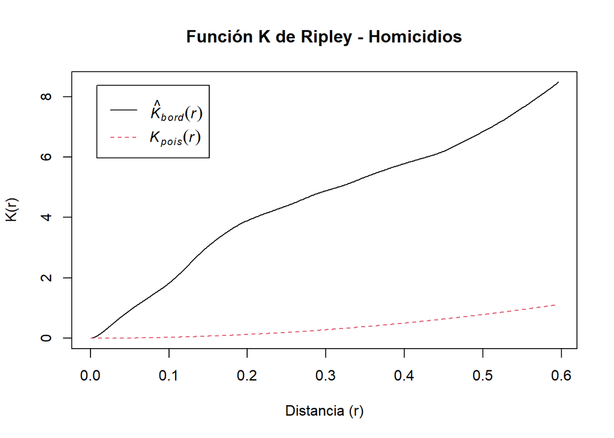

Esto confirma estadísticamente que los homicidios no ocurren al azar. No se distribuyen de manera uniforme (como si cayeran gotas de lluvia aleatorias sobre el mapa), sino que existen zonas con una alta concentración de eventos (puntos calientes o *hotspots*).